# Figure 2: Mitochondrial and spine ATP

# Fig 2D

Mitochondrial ATP reporter L/F in juxtaspinal and non-juxtaspinal regions after homeostatic plasticity.

**Source data**  
`Fig 2D.csv`

**Columns**

- `Date` — Experiment date
- `Condition` — Control or TTX
- `Dish` — Culture dish ID
- `Cell` — Cell ID
- `dendrite` — Dendrite ID
- `mito` — Mitochondrial region ID
- `Slice` — Image slice ID
- `L` — Luciferase luminescence
- `F` — Reporter fluorescence
- `LbyF` — Luminescence-to-fluorescence ratio (L/F)
- `Region` — Juxtaspinal or non-juxtaspinal region

## Data

The analysis uses regions with positive luminescence and fluorescence above 500.

```r
spacing_map <- c("Juxta Control" = 1, "Juxta TTX" = 2.2, "Non Juxta Control" = 3.8, "Non Juxta TTX" = 5)
LbyF_df <- read_csv("./Fig 2D.csv", show_col_types = FALSE) %>%
  transmute(Date = trimws(as.character(Date)), Condition = trimws(as.character(Condition)),
            Dish = as.integer(parse_number(as.character(Dish))), Cell = as.integer(parse_number(as.character(Cell))),
            dendrite = as.integer(dendrite), mito = as.integer(mito), Region = trimws(as.character(Region)),
            LbyF = as.numeric(LbyF), L = as.numeric(L), F = as.numeric(F)) %>%
  filter(Condition %in% c("Control", "TTX"), Region %in% c("Juxta", "Non Juxta"),
         Date != "", is.finite(LbyF), is.finite(L), is.finite(F), L > 0, F > 500) %>%
  mutate(Date = factor(Date), Condition = factor(Condition, levels = c("Control", "TTX")),
         Region = factor(Region, levels = c("Juxta", "Non Juxta")),
         Group = factor(paste(Region, Condition), levels = names(spacing_map)),
         x_pos = unname(spacing_map[as.character(Group)]), Group_Date = paste(Group, Date, sep = "_"))
if (!nrow(LbyF_df)) stop("No valid Fig 2D measurements remain.")
LbyF_df %>% mutate(across(where(is.numeric), ~ round(.x, 3)))
```

| Date | Condition | Dish | Cell | dendrite | mito | Region | LbyF | L | F | Group | x_pos | Group_Date |
| --- | --- | --- | --- | --- | --- | --- | --- | --- | --- | --- | --- | --- |
| 2025-07-22 | Control | 2 | 1 | 1 | 1 | Juxta | 0.062 | 41.861 | 670.389 | Juxta Control | 1.0 | Juxta Control_2025-07-22 |
| 2025-07-22 | Control | 2 | 1 | 1 | 2 | Juxta | 0.038 | 49.969 | 1300.250 | Juxta Control | 1.0 | Juxta Control_2025-07-22 |
| 2025-07-22 | Control | 2 | 1 | 1 | 3 | Juxta | 0.071 | 37.179 | 521.359 | Juxta Control | 1.0 | Juxta Control_2025-07-22 |
| 2025-07-22 | Control | 2 | 1 | 1 | 5 | Juxta | 0.053 | 45.200 | 847.480 | Juxta Control | 1.0 | Juxta Control_2025-07-22 |
| 2025-07-22 | Control | 2 | 1 | 1 | 7 | Juxta | 0.067 | 40.786 | 605.667 | Juxta Control | 1.0 | Juxta Control_2025-07-22 |
| 2025-07-22 | Control | 2 | 1 | 1 | 8 | Juxta | 0.060 | 35.396 | 585.854 | Juxta Control | 1.0 | Juxta Control_2025-07-22 |
| 2025-07-22 | Control | 2 | 1 | 1 | 9 | Juxta | 0.051 | 29.359 | 576.564 | Juxta Control | 1.0 | Juxta Control_2025-07-22 |
| 2025-07-22 | Control | 2 | 1 | 1 | 10 | Juxta | 0.051 | 47.053 | 927.395 | Juxta Control | 1.0 | Juxta Control_2025-07-22 |
| 2025-07-22 | Control | 2 | 1 | 1 | 11 | Juxta | 0.055 | 39.809 | 720.128 | Juxta Control | 1.0 | Juxta Control_2025-07-22 |
| 2025-07-22 | Control | 2 | 1 | 1 | 12 | Juxta | 0.050 | 40.700 | 818.067 | Juxta Control | 1.0 | Juxta Control_2025-07-22 |

[output cut: 795 more lines]

## Summary

```r
summary_table <- LbyF_df %>% group_by(Region, Condition, Group) %>%
  summarise(n_Mitochondria = n_distinct(Date, Dish, Cell, dendrite, mito),
            n_Dendrites = n_distinct(Date, Dish, Cell, dendrite),
            n_Cells = n_distinct(Date, Dish, Cell), n_Experiment_Dates = n_distinct(Date),
            `Mean (SE)` = sprintf("%.3f (%.3f)", mean(LbyF), sd(LbyF) / sqrt(n())), .groups = "drop")
summary_table
```

| Region | Condition | Group | n_Mitochondria | n_Dendrites | n_Cells | n_Experiment_Dates | Mean (SE) |
| --- | --- | --- | --- | --- | --- | --- | --- |
| Juxta | Control | Juxta Control | 352 | 59 | 21 | 3 | 0.087 (0.002) |
| Juxta | TTX | Juxta TTX | 269 | 55 | 23 | 3 | 0.096 (0.002) |
| Non Juxta | Control | Non Juxta Control | 133 | 27 | 14 | 3 | 0.058 (0.002) |
| Non Juxta | TTX | Non Juxta TTX | 51 | 22 | 11 | 3 | 0.081 (0.004) |

## Statistics

Three-way ANOVA with condition, region, experiment date, and their interactions (Type I sums of squares). Pairwise comparisons use Tukey adjustment.

```r
format_p <- function(p) ifelse(p < 0.0001, "<0.0001", sprintf("%.4f", p))
p_to_stars <- function(p) case_when(p < 0.001 ~ "***", p < 0.01 ~ "**", p < 0.05 ~ "*", TRUE ~ "ns")
fit_aov <- aov(LbyF ~ Condition * Region * Date, data = LbyF_df)
aov_tab <- anova(fit_aov)
anova_table <- as.data.frame(aov_tab) %>% tibble::rownames_to_column("Effect") %>%
  filter(trimws(Effect) != "Residuals") %>%
  transmute(Effect = dplyr::recode(trimws(Effect), Condition = "Condition", Region = "Region", Date = "Date",
                                   `Condition:Region` = "Condition x Region",
                                   `Condition:Date` = "Condition x Date",
                                   `Region:Date` = "Region x Date",
                                   `Condition:Region:Date` = "Condition x Region x Date"),
            df = Df, F = round(`F value`, 3), `p value` = format_p(`Pr(>F)`))
anova_table
```

| Effect | df | F | p value |
| --- | --- | --- | --- |
| Condition | 1 | 48.957 | <0.0001 |
| Region | 1 | 106.021 | <0.0001 |
| Date | 2 | 35.683 | <0.0001 |
| Condition x Region | 1 | 2.454 | 0.1176 |
| Condition x Date | 2 | 24.354 | <0.0001 |
| Region x Date | 2 | 3.994 | 0.0188 |
| Condition x Region x Date | 2 | 1.703 | 0.1827 |

```r
cell_emm <- emmeans::emmeans(fit_aov, ~ Region * Condition)
all_pairs <- as.data.frame(emmeans::contrast(cell_emm, "pairwise", adjust = "tukey"))
pair_parts <- strsplit(as.character(all_pairs$contrast), " - ", fixed = TRUE)
pair_key <- function(x, y) paste(sort(c(x, y)), collapse = "|")
all_pairs <- all_pairs %>%
  mutate(group1 = vapply(pair_parts, `[`, character(1), 1),
         group2 = vapply(pair_parts, `[`, character(1), 2),
         pair = mapply(pair_key, group1, group2))

comparison_results <- tibble(
  group1 = c("Juxta Control", "Non Juxta Control", "Juxta Control", "Juxta TTX"),
  group2 = c("Juxta TTX", "Non Juxta TTX", "Non Juxta Control", "Non Juxta TTX")
) %>%
  mutate(pair = mapply(pair_key, group1, group2)) %>%
  left_join(all_pairs %>% select(pair, p_value = p.value), by = "pair") %>% select(-pair)

group_means <- setNames(summary_table$`Mean (SE)`, as.character(summary_table$Group))
stats_table <- comparison_results %>%
  transmute(Test = "Three-way ANOVA with Tukey post hoc", Comparison = paste(group1, "vs", group2),
            `First mean (SE)` = unname(group_means[group1]),
            `Second mean (SE)` = unname(group_means[group2]),
            `Condition p` = format_p(aov_tab["Condition", "Pr(>F)"]),
            `Region p` = format_p(aov_tab["Region", "Pr(>F)"]),
            `Condition x Region p` = format_p(aov_tab["Condition:Region", "Pr(>F)"]),
            `Tukey p` = format_p(p_value))
stats_table
```

| Test | Comparison | First mean (SE) | Second mean (SE) | Condition p | Region p | Condition x Region p | Tukey p |
| --- | --- | --- | --- | --- | --- | --- | --- |
| Three-way ANOVA with Tukey post hoc | Juxta Control vs Juxta TTX | 0.087 (0.002) | 0.096 (0.002) | <0.0001 | <0.0001 | 0.1176 | <0.0001 |
| Three-way ANOVA with Tukey post hoc | Non Juxta Control vs Non Juxta TTX | 0.058 (0.002) | 0.081 (0.004) | <0.0001 | <0.0001 | 0.1176 | <0.0001 |
| Three-way ANOVA with Tukey post hoc | Juxta Control vs Non Juxta Control | 0.087 (0.002) | 0.058 (0.002) | <0.0001 | <0.0001 | 0.1176 | <0.0001 |
| Three-way ANOVA with Tukey post hoc | Juxta TTX vs Non Juxta TTX | 0.096 (0.002) | 0.081 (0.004) | <0.0001 | <0.0001 | 0.1176 | 0.0021 |

## Plot

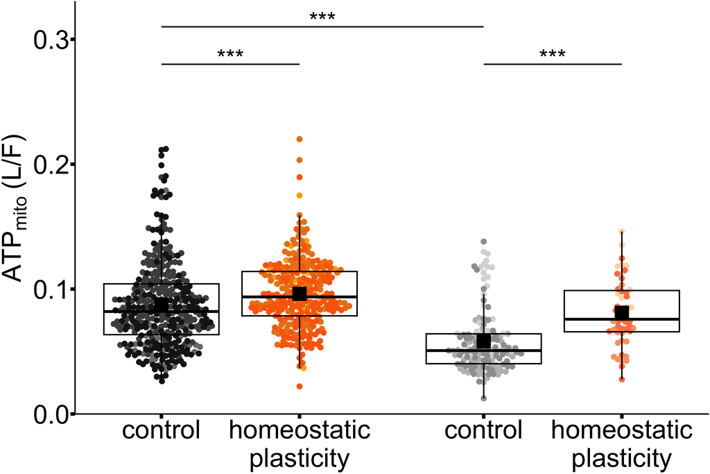

```r
set.seed(20261109)
date_levels <- levels(LbyF_df$Date)
group_date_colors <- c(
  setNames(rep(c("#1A1A1A", "#4D4D4D", "#777B7E"), length.out = length(date_levels)), paste("Juxta Control", date_levels, sep = "_")),
  setNames(rep(c("#FC6A03", "#ED820E", "#FFAD00"), length.out = length(date_levels)), paste("Juxta TTX", date_levels, sep = "_")),
  setNames(rep(c("#9E9E9E", "#D9D9D9", "#BDBDBD"), length.out = length(date_levels)), paste("Non Juxta Control", date_levels, sep = "_")),
  setNames(rep(c("#FDA172", "#FF7F50", "#FED8B1"), length.out = length(date_levels)), paste("Non Juxta TTX", date_levels, sep = "_"))
)
plot_stats <- comparison_results %>%
  filter(!(group1 == "Juxta TTX" & group2 == "Non Juxta TTX")) %>%
  mutate(group1_x = unname(spacing_map[group1]), group2_x = unname(spacing_map[group2]),
         y_position = if_else(group1 == "Juxta Control" & group2 == "Non Juxta Control", 0.31, 0.28),
         stars = p_to_stars(p_value)) %>% filter(stars != "ns")

fig2d_plot <- ggplot(LbyF_df, aes(x_pos, LbyF, color = Group_Date)) +
  ggbeeswarm::geom_beeswarm(cex = 1, priority = "random", size = 8, corral = "random") +
  geom_boxplot(aes(group = x_pos), fill = NA, width = 1, outlier.shape = NA, linewidth = 2, color = "black") +
  stat_summary(aes(group = x_pos), fun = mean, geom = "point", shape = 15, size = 20, color = "black") +
  geom_segment(data = plot_stats, aes(x = group1_x, xend = group2_x, y = y_position, yend = y_position),
               inherit.aes = FALSE, linewidth = 2, color = "black") +
  geom_text(data = plot_stats, aes(x = (group1_x + group2_x) / 2, y = y_position + 0.005, label = stars),
            inherit.aes = FALSE, size = 25, color = "black") +
  scale_x_continuous(breaks = unname(spacing_map),
                     labels = c("control", "homeostatic\nplasticity", "control", "homeostatic\nplasticity")) +
  scale_color_manual(values = group_date_colors) +
  scale_y_continuous(oob = scales::oob_keep, breaks = c(0, 0.1, 0.2, 0.3), limits = c(0, 0.33), expand = c(0, 0)) +
  labs(x = NULL, y = expression(ATP[mito]~"(L/F)")) +
  theme_classic() +
  theme(axis.title = element_text(size = 80, color = "black"),
        axis.text = element_text(size = 80, color = "black"),
        axis.ticks = element_line(linewidth = 5, color = "black"),
        axis.ticks.length = grid::unit(0.5, "cm"),
        axis.line = element_line(linewidth = 2, color = "black"),
        legend.position = "none")
fig2d_plot
```

# Fig 2E

Mitochondrial ATP reporter L/F after MPC1 knockdown, by region and homeostatic-plasticity treatment.

**Source data**  
`Fig 2E.csv`

**Columns**

- `Date` — Experiment date
- `Condition` — Control or TTX after MPC1 knockdown
- `Dish` — Culture dish ID
- `Cell` — Cell ID
- `FOV` — Field of view ID
- `mito` — Mitochondrial region ID
- `Slice` — Image slice ID
- `L` — Luciferase luminescence
- `F` — Reporter fluorescence
- `LbyF` — Luminescence-to-fluorescence ratio (L/F)
- `Region` — Juxtaspinal or non-juxtaspinal region

## Data

```r
spacing_map <- c("Juxta Control" = 1, "Juxta TTX" = 2.2, "Non Juxta Control" = 3.8, "Non Juxta TTX" = 5)
LbyF_df <- read_csv("./Fig 2E.csv", show_col_types = FALSE) %>%
  transmute(Date = trimws(as.character(Date)), Condition = trimws(as.character(Condition)),
            Dish = as.integer(parse_number(as.character(Dish))), Cell = as.integer(parse_number(as.character(Cell))),
            mito = as.integer(mito), Region = trimws(as.character(Region)),
            LbyF = as.numeric(LbyF), L = as.numeric(L), F = as.numeric(F)) %>%
  filter(Condition %in% c("Control", "TTX"), Region %in% c("Juxta", "Non Juxta"),
         Date != "", is.finite(LbyF), is.finite(L), is.finite(F), L > 0, F > 500) %>%
  mutate(Date = factor(Date), Condition = factor(Condition, levels = c("Control", "TTX")),
         Region = factor(Region, levels = c("Juxta", "Non Juxta")),
         Group = factor(paste(Region, Condition), levels = names(spacing_map)),
         x_pos = unname(spacing_map[as.character(Group)]), Group_Date = paste(Group, Date, sep = "_"))
if (!nrow(LbyF_df)) stop("No valid Fig 2E measurements remain.")
LbyF_df %>% mutate(across(where(is.numeric), ~ round(.x, 3)))
```

| Date | Condition | Dish | Cell | mito | Region | LbyF | L | F | Group | x_pos | Group_Date |
| --- | --- | --- | --- | --- | --- | --- | --- | --- | --- | --- | --- |
| 2026-05-20 | Control | 2 | 2 | 1 | Juxta | 0.082 | 76.984 | 939.852 | Juxta Control | 1.0 | Juxta Control_2026-05-20 |
| 2026-05-20 | Control | 2 | 2 | 2 | Juxta | 0.061 | 80.724 | 1325.690 | Juxta Control | 1.0 | Juxta Control_2026-05-20 |
| 2026-05-20 | Control | 2 | 2 | 3 | Juxta | 0.058 | 161.458 | 2781.500 | Juxta Control | 1.0 | Juxta Control_2026-05-20 |
| 2026-05-20 | Control | 2 | 2 | 4 | Juxta | 0.074 | 61.853 | 838.382 | Juxta Control | 1.0 | Juxta Control_2026-05-20 |
| 2026-05-20 | Control | 2 | 2 | 5 | Juxta | 0.071 | 100.660 | 1408.500 | Juxta Control | 1.0 | Juxta Control_2026-05-20 |
| 2026-05-20 | Control | 2 | 2 | 6 | Juxta | 0.071 | 87.909 | 1246.864 | Juxta Control | 1.0 | Juxta Control_2026-05-20 |
| 2026-05-20 | Control | 2 | 2 | 7 | Juxta | 0.060 | 63.065 | 1052.774 | Juxta Control | 1.0 | Juxta Control_2026-05-20 |
| 2026-05-20 | Control | 2 | 2 | 8 | Juxta | 0.063 | 56.913 | 901.522 | Juxta Control | 1.0 | Juxta Control_2026-05-20 |
| 2026-05-20 | Control | 2 | 2 | 9 | Juxta | 0.075 | 73.788 | 988.606 | Juxta Control | 1.0 | Juxta Control_2026-05-20 |
| 2026-05-20 | Control | 2 | 2 | 10 | Juxta | 0.075 | 64.613 | 864.290 | Juxta Control | 1.0 | Juxta Control_2026-05-20 |

[output cut: 501 more lines]

## Summary

```r
summary_table <- LbyF_df %>% group_by(Region, Condition, Group) %>%
  summarise(n_Mitochondria = n_distinct(Date, Dish, Cell, mito),
            n_Cells = n_distinct(Date, Dish, Cell), n_Experiment_Dates = n_distinct(Date),
            `Mean (SE)` = sprintf("%.3f (%.3f)", mean(LbyF), sd(LbyF) / sqrt(n())), .groups = "drop")
summary_table
```

| Region | Condition | Group | n_Mitochondria | n_Cells | n_Experiment_Dates | Mean (SE) |
| --- | --- | --- | --- | --- | --- | --- |
| Juxta | Control | Juxta Control | 192 | 12 | 3 | 0.120 (0.003) |
| Juxta | TTX | Juxta TTX | 171 | 12 | 3 | 0.085 (0.003) |
| Non Juxta | Control | Non Juxta Control | 70 | 11 | 3 | 0.106 (0.004) |
| Non Juxta | TTX | Non Juxta TTX | 57 | 12 | 3 | 0.079 (0.003) |

## Statistics

Three-way ANOVA with condition, region, experiment date, and their interactions (Type I sums of squares). Pairwise comparisons use Tukey adjustment.

```r
format_p <- function(p) ifelse(p < 0.0001, "<0.0001", sprintf("%.4f", p))
p_to_stars <- function(p) case_when(p < 0.001 ~ "***", p < 0.01 ~ "**", p < 0.05 ~ "*", TRUE ~ "ns")
fit_aov <- aov(LbyF ~ Condition * Region * Date, data = LbyF_df)
aov_tab <- anova(fit_aov)
anova_table <- as.data.frame(aov_tab) %>% tibble::rownames_to_column("Effect") %>%
  filter(trimws(Effect) != "Residuals") %>%
  transmute(Effect = dplyr::recode(trimws(Effect), Condition = "Condition", Region = "Region", Date = "Date",
                                   `Condition:Region` = "Condition x Region",
                                   `Condition:Date` = "Condition x Date",
                                   `Region:Date` = "Region x Date",
                                   `Condition:Region:Date` = "Condition x Region x Date"),
            df = Df, F = round(`F value`, 3), `p value` = format_p(`Pr(>F)`))
anova_table
```

| Effect | df | F | p value |
| --- | --- | --- | --- |
| Condition | 1 | 113.693 | <0.0001 |
| Region | 1 | 8.001 | 0.0049 |
| Date | 2 | 0.995 | 0.3704 |
| Condition x Region | 1 | 1.403 | 0.2367 |
| Condition x Date | 2 | 82.465 | <0.0001 |
| Region x Date | 2 | 0.448 | 0.6391 |
| Condition x Region x Date | 2 | 4.712 | 0.0094 |

```r
cell_emm <- emmeans::emmeans(fit_aov, ~ Region * Condition)
all_pairs <- as.data.frame(emmeans::contrast(cell_emm, "pairwise", adjust = "tukey"))
pair_parts <- strsplit(as.character(all_pairs$contrast), " - ", fixed = TRUE)
pair_key <- function(x, y) paste(sort(c(x, y)), collapse = "|")
all_pairs <- all_pairs %>%
  mutate(group1 = vapply(pair_parts, `[`, character(1), 1),
         group2 = vapply(pair_parts, `[`, character(1), 2),
         pair = mapply(pair_key, group1, group2))

comparison_results <- tibble(
  group1 = c("Juxta Control", "Non Juxta Control", "Juxta Control", "Juxta TTX"),
  group2 = c("Juxta TTX", "Non Juxta TTX", "Non Juxta Control", "Non Juxta TTX")
) %>%
  mutate(pair = mapply(pair_key, group1, group2)) %>%
  left_join(all_pairs %>% select(pair, p_value = p.value), by = "pair") %>% select(-pair)

group_means <- setNames(summary_table$`Mean (SE)`, as.character(summary_table$Group))
stats_table <- comparison_results %>%
  transmute(Test = "Three-way ANOVA with Tukey post hoc", Comparison = paste(group1, "vs", group2),
            `First mean (SE)` = unname(group_means[group1]),
            `Second mean (SE)` = unname(group_means[group2]),
            `Condition p` = format_p(aov_tab["Condition", "Pr(>F)"]),
            `Region p` = format_p(aov_tab["Region", "Pr(>F)"]),
            `Condition x Region p` = format_p(aov_tab["Condition:Region", "Pr(>F)"]),
            `Tukey p` = format_p(p_value))
stats_table
```

| Test | Comparison | First mean (SE) | Second mean (SE) | Condition p | Region p | Condition x Region p | Tukey p |
| --- | --- | --- | --- | --- | --- | --- | --- |
| Three-way ANOVA with Tukey post hoc | Juxta Control vs Juxta TTX | 0.120 (0.003) | 0.085 (0.003) | <0.0001 | 0.0049 | 0.2367 | <0.0001 |
| Three-way ANOVA with Tukey post hoc | Non Juxta Control vs Non Juxta TTX | 0.106 (0.004) | 0.079 (0.003) | <0.0001 | 0.0049 | 0.2367 | <0.0001 |
| Three-way ANOVA with Tukey post hoc | Juxta Control vs Non Juxta Control | 0.120 (0.003) | 0.106 (0.004) | <0.0001 | 0.0049 | 0.2367 | 0.0640 |
| Three-way ANOVA with Tukey post hoc | Juxta TTX vs Non Juxta TTX | 0.085 (0.003) | 0.079 (0.003) | <0.0001 | 0.0049 | 0.2367 | 0.5542 |

## Plot

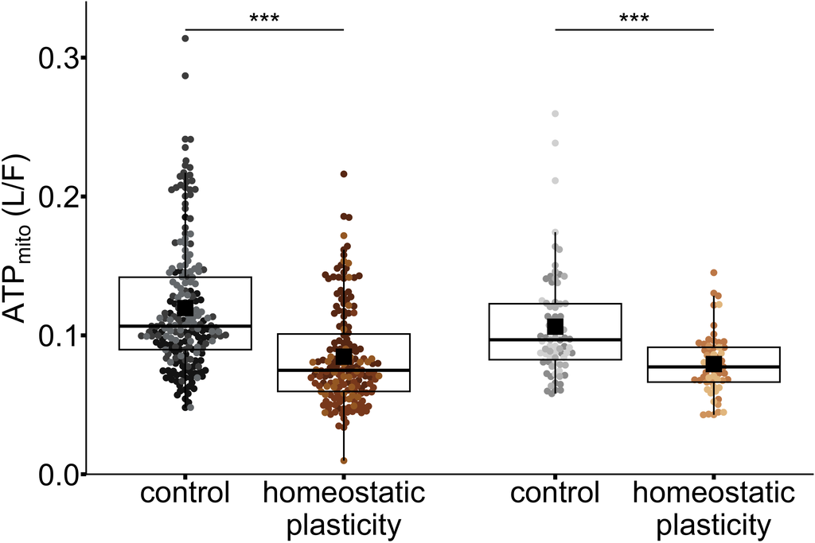

```r
set.seed(20261109)
date_levels <- levels(LbyF_df$Date)
group_date_colors <- c(
  setNames(rep(c("#1A1A1A", "#4D4D4D", "#777B7E"), length.out = length(date_levels)), paste("Juxta Control", date_levels, sep = "_")),
  setNames(rep(c("#6B3518", "#8C4A24", "#A66A2C"), length.out = length(date_levels)), paste("Juxta TTX", date_levels, sep = "_")),
  setNames(rep(c("#9E9E9E", "#D9D9D9", "#BDBDBD"), length.out = length(date_levels)), paste("Non Juxta Control", date_levels, sep = "_")),
  setNames(rep(c("#C98A57", "#D9A46F", "#E8C28F"), length.out = length(date_levels)), paste("Non Juxta TTX", date_levels, sep = "_"))
)
plot_stats <- comparison_results %>%
  filter((group1 == "Juxta Control" & group2 == "Juxta TTX") |
         (group1 == "Non Juxta Control" & group2 == "Non Juxta TTX")) %>%
  mutate(group1_x = unname(spacing_map[group1]), group2_x = unname(spacing_map[group2]),
         y_position = 0.32, stars = p_to_stars(p_value)) %>% filter(stars != "ns")

fig2e_plot <- ggplot(LbyF_df, aes(x_pos, LbyF, color = Group_Date)) +
  ggbeeswarm::geom_beeswarm(cex = 1, priority = "random", size = 8, corral = "random") +
  geom_boxplot(aes(group = x_pos), fill = NA, width = 1, outlier.shape = NA, linewidth = 2, color = "black") +
  stat_summary(aes(group = x_pos), fun = mean, geom = "point", shape = 15, size = 20, color = "black") +
  geom_segment(data = plot_stats, aes(x = group1_x, xend = group2_x, y = y_position, yend = y_position),
               inherit.aes = FALSE, linewidth = 2, color = "black") +
  geom_text(data = plot_stats, aes(x = (group1_x + group2_x) / 2, y = y_position + 0.005, label = stars),
            inherit.aes = FALSE, size = 25, color = "black") +
  scale_x_continuous(breaks = unname(spacing_map),
                     labels = c("control", "homeostatic\nplasticity", "control", "homeostatic\nplasticity")) +
  scale_color_manual(values = group_date_colors) +
  scale_y_continuous(oob = scales::oob_keep, breaks = c(0, 0.1, 0.2, 0.3), limits = c(0, 0.34), expand = c(0, 0)) +
  labs(x = NULL, y = expression(ATP[mito]~"(L/F)")) +
  theme_classic() +
  theme(axis.title = element_text(size = 80, color = "black"),
        axis.text = element_text(size = 80, color = "black"),
        axis.ticks = element_line(linewidth = 5, color = "black"),
        axis.ticks.length = grid::unit(0.5, "cm"),
        axis.line = element_line(linewidth = 2, color = "black"),
        legend.position = "none")
fig2e_plot
```

# Fig 2H

Spine ATP reporter L/F after homeostatic plasticity in the wild-type dataset.

**Source data**  
`Fig 2H.csv`

**Columns**

- `Date` — Experiment date
- `Condition` — Control or TTX
- `Dish` — Culture dish ID
- `Cell` — Cell ID
- `L` — Luciferase luminescence
- `F` — Reporter fluorescence
- `LbyF` — Luminescence-to-fluorescence ratio (L/F)

## Data

Control and TTX observations are used in this panel.

```r
suppressPackageStartupMessages({
  library(dplyr); library(readr); library(ggplot2); library(ggbeeswarm)
})
spacing_map <- c("Control" = 1, "TTX" = 2.2)
LbyF_df <- read_csv("./Fig 2H.csv", show_col_types = FALSE) %>%
  mutate(Condition = factor(trimws(as.character(Condition)), levels = names(spacing_map)),
         Date = factor(trimws(as.character(Date))), LbyF = as.numeric(LbyF),
         x_pos = unname(spacing_map[as.character(Condition)]),
         Date_Condition = paste(Condition, Date, sep = "_")) %>%
  filter(!is.na(Condition), !is.na(Date), is.finite(LbyF))
LbyF_df %>% mutate(across(where(is.numeric), ~ round(.x, 3)))
```

| Date | Condition | Dish | Cell | L | F | LbyF | mito_area | date_id | cell_id_nested | x_pos | Date_Condition |
| --- | --- | --- | --- | --- | --- | --- | --- | --- | --- | --- | --- |
| 2025-05-27 | Control | 1 | 1 | 133.762 | 642.714 | 0.208 | 1.72 | 1 | 1 | 1.0 | Control_2025-05-27 |
| 2025-05-27 | Control | 1 | 1 | 157.000 | 819.048 | 0.192 | 2.52 | 1 | 1 | 1.0 | Control_2025-05-27 |
| 2025-05-27 | Control | 1 | 1 | 70.619 | 428.333 | 0.165 | 1.96 | 1 | 1 | 1.0 | Control_2025-05-27 |
| 2025-05-27 | Control | 1 | 1 | 110.762 | 707.952 | 0.156 | 1.36 | 1 | 1 | 1.0 | Control_2025-05-27 |
| 2025-05-27 | Control | 1 | 1 | 118.857 | 595.381 | 0.200 | 2.52 | 1 | 1 | 1.0 | Control_2025-05-27 |
| 2025-05-27 | Control | 1 | 1 | 134.619 | 707.095 | 0.190 | 1.20 | 1 | 1 | 1.0 | Control_2025-05-27 |
| 2025-05-27 | Control | 1 | 1 | 154.238 | 856.524 | 0.180 | 1.84 | 1 | 1 | 1.0 | Control_2025-05-27 |
| 2025-05-27 | Control | 1 | 2 | 141.381 | 826.857 | 0.171 | 2.08 | 1 | 2 | 1.0 | Control_2025-05-27 |
| 2025-05-27 | Control | 1 | 2 | 136.048 | 690.238 | 0.197 | 1.16 | 1 | 2 | 1.0 | Control_2025-05-27 |
| 2025-05-27 | Control | 1 | 2 | 85.619 | 480.190 | 0.178 | 1.16 | 1 | 2 | 1.0 | Control_2025-05-27 |

[output cut: 581 more lines]

## Summary

```r
summary_table <- LbyF_df %>% group_by(Condition) %>%
  summarise(n_Spines = n(), n_Cells = n_distinct(Date, Dish, Cell),
            n_Experiment_Dates = n_distinct(Date), .groups = "drop")
summary_table
```

| Condition | n_Spines | n_Cells | n_Experiment_Dates |
| --- | --- | --- | --- |
| Control | 343 | 38 | 3 |
| TTX | 248 | 18 | 3 |

## Statistics

Two-way ANOVA with condition, experiment date, and their interaction (Type I sums of squares).

```r
fit_aov <- aov(LbyF ~ Condition * Date, data = LbyF_df)
condition_p <- as.numeric(anova(fit_aov)["Condition", "Pr(>F)"])
format_p <- function(p) ifelse(p < 0.0001, "<0.0001", sprintf("%.4f", p))
p_to_stars <- function(p) case_when(p < 0.001 ~ "***", p < 0.01 ~ "**", p < 0.05 ~ "*", TRUE ~ "ns")
group_means <- LbyF_df %>% group_by(Condition) %>%
  summarise(mean = mean(LbyF), SE = sd(LbyF) / sqrt(n()), .groups = "drop")
stats_table <- tibble(
  Test = "Two-way ANOVA", Comparison = "Control vs TTX",
  `Control mean (SE)` = sprintf("%.3f (%.3f)", group_means$mean[1], group_means$SE[1]),
  `TTX mean (SE)` = sprintf("%.3f (%.3f)", group_means$mean[2], group_means$SE[2]),
  `Condition p` = format_p(condition_p)
)
stats_table
```

| Test | Comparison | Control mean (SE) | TTX mean (SE) | Condition p |
| --- | --- | --- | --- | --- |
| Two-way ANOVA | Control vs TTX | 0.152 (0.003) | 0.262 (0.006) | <0.0001 |

```r
anova(fit_aov)
```

|  | Df | Sum Sq | Mean Sq | F value | Pr(>F) |
| --- | --- | --- | --- | --- | --- |
| Condition | 1 | 1.7212168 | 1.721216796 | 280.734598 | 9.316164e-52 |
| Date | 2 | 0.2386133 | 0.119306638 | 19.459200 | 6.579780e-09 |
| Condition:Date | 2 | 0.0208347 | 0.010417349 | 1.699095 | 1.837501e-01 |
| Residuals | 585 | 3.5867037 | 0.006131117 | NA | NA |

## Plot

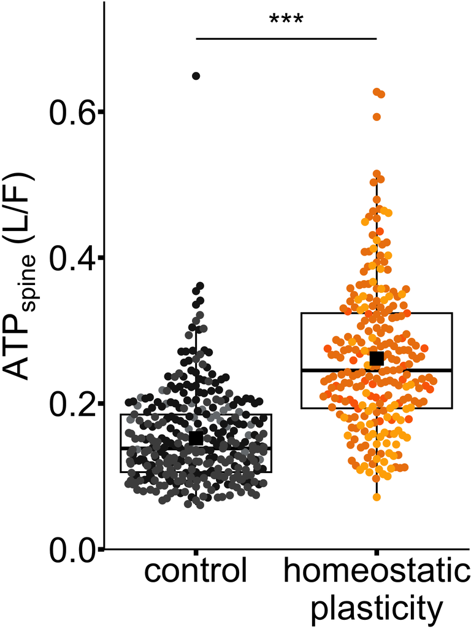

```r
set.seed(20261109)
date_levels <- levels(LbyF_df$Date)
date_colors <- c(
  setNames(rep(c("#777B7E", "#1A1A1A", "#4D4D4D"), length.out = length(date_levels)), paste("Control", date_levels, sep = "_")),
  setNames(rep(c("#FC6A03", "#ED820E", "#FFAD00"), length.out = length(date_levels)), paste("TTX", date_levels, sep = "_"))
)
plot_stats <- tibble(group1_x = 1, group2_x = 2.2, stars = p_to_stars(condition_p)) %>% filter(stars != "ns")
fig2h_plot <- ggplot(LbyF_df, aes(x_pos, LbyF, color = Date_Condition)) +
  geom_boxplot(aes(group = x_pos), fill = NA, width = 1, outlier.shape = NA, linewidth = 2, color = "black") +
  ggbeeswarm::geom_beeswarm(cex = 2.5, priority = "random", size = 8, corral = "random") +
  stat_summary(aes(group = x_pos), fun = mean, geom = "point", shape = 15, size = 15, color = "black") +
  geom_segment(data = plot_stats, aes(x = group1_x, xend = group2_x, y = 0.70, yend = 0.70),
               inherit.aes = FALSE, linewidth = 2, color = "black") +
  geom_text(data = plot_stats, aes(x = (group1_x + group2_x) / 2, y = 0.72, label = stars),
            inherit.aes = FALSE, size = 25, color = "black") +
  scale_x_continuous(breaks = unname(spacing_map), labels = c("control", "homeostatic\nplasticity")) +
  scale_color_manual(values = date_colors) +
  scale_y_continuous(breaks = c(0, 0.2, 0.4, 0.6), expand = c(0, 0)) +
  coord_cartesian(ylim = c(0, 0.75)) +
  labs(x = NULL, y = expression(ATP[spine]~"(L/F)")) +
  theme_classic() +
  theme(axis.title = element_text(size = 80, color = "black"),
        axis.text = element_text(size = 80, color = "black"),
        axis.ticks = element_line(linewidth = 5, color = "black"),
        axis.ticks.length = grid::unit(0.5, "cm"),
        axis.line = element_line(linewidth = 2, color = "black"),
        legend.position = "none")
fig2h_plot
```

# Fig 2I

Spine ATP reporter L/F following homeostatic plasticity after MPC1 knockdown.

**Source data**  
`Fig 2I.csv`

**Columns**

- `Date` — Experiment date
- `Condition` — Control or TTX after MPC1 knockdown
- `Dish` — Culture dish ID
- `Cell` — Cell ID
- `Spine` — Spine ID
- `Slice` — Image slice ID
- `L` — Luciferase luminescence
- `F` — Reporter fluorescence
- `LbyF` — Luminescence-to-fluorescence ratio (L/F)

## Data

```r
suppressPackageStartupMessages({
  library(dplyr); library(readr); library(ggplot2); library(ggbeeswarm)
})
PLOT_CORRECTED <- TRUE
pH_control <- 6.92; pH_scaling <- 6.87
pKa_L <- 7.03; pKa_F <- 6.5
L_corr_factor <- (1 + 10^(pKa_L - pH_scaling)) / (1 + 10^(pKa_L - pH_control))
F_corr_factor <- (1 + 10^(pKa_F - pH_scaling)) / (1 + 10^(pKa_F - pH_control))
plot_y <- if (PLOT_CORRECTED) "LbyF_corrected" else "LbyF"
spacing_map <- c("Control" = 1, "TTX" = 2.2)

LbyF_df <- read_csv("./Fig 2I.csv", show_col_types = FALSE) %>%
  mutate(Date = trimws(as.character(Date)), Condition = trimws(as.character(Condition)),
         L = as.numeric(L), F = as.numeric(F), LbyF = as.numeric(LbyF),
         L_corrected = if_else(Condition %in% c("TTX", "TTX MPC1KD"), L * L_corr_factor, L),
         F_corrected = if_else(Condition %in% c("TTX", "TTX MPC1KD"), F * F_corr_factor, F),
         LbyF_corrected = L_corrected / F_corrected) %>%
  filter(Condition %in% names(spacing_map), Date != "", is.finite(.data[[plot_y]])) %>%
  mutate(Condition = factor(Condition, levels = names(spacing_map)), Date = factor(Date),
         x_pos = unname(spacing_map[as.character(Condition)]),
         Date_Condition = paste(Condition, Date, sep = "_"))
LbyF_df %>% mutate(across(where(is.numeric), ~ round(.x, 3)))
```

| Date | Condition | Dish | Cell | Spine | Slice | L | F | LbyF | L_corrected | F_corrected | LbyF_corrected | x_pos | Date_Condition |
| --- | --- | --- | --- | --- | --- | --- | --- | --- | --- | --- | --- | --- | --- |
| 2026-05-06 | Control | 3 | 1 | 1 | 1 | 256.762 | 2549.000 | 0.101 | 256.762 | 2549.000 | 0.101 | 1.0 | Control_2026-05-06 |
| 2026-05-06 | Control | 3 | 1 | 2 | 1 | 308.524 | 3004.905 | 0.103 | 308.524 | 3004.905 | 0.103 | 1.0 | Control_2026-05-06 |
| 2026-05-06 | Control | 3 | 1 | 3 | 1 | 129.286 | 1154.048 | 0.112 | 129.286 | 1154.048 | 0.112 | 1.0 | Control_2026-05-06 |
| 2026-05-06 | Control | 3 | 1 | 4 | 1 | 304.762 | 3984.000 | 0.076 | 304.762 | 3984.000 | 0.076 | 1.0 | Control_2026-05-06 |
| 2026-05-06 | Control | 3 | 1 | 5 | 1 | 222.571 | 3183.190 | 0.070 | 222.571 | 3183.190 | 0.070 | 1.0 | Control_2026-05-06 |
| 2026-05-06 | Control | 3 | 1 | 6 | 1 | 204.667 | 2250.810 | 0.091 | 204.667 | 2250.810 | 0.091 | 1.0 | Control_2026-05-06 |
| 2026-05-06 | Control | 3 | 1 | 7 | 1 | 224.905 | 3365.048 | 0.067 | 224.905 | 3365.048 | 0.067 | 1.0 | Control_2026-05-06 |
| 2026-05-06 | Control | 3 | 1 | 8 | 1 | 327.048 | 4042.143 | 0.081 | 327.048 | 4042.143 | 0.081 | 1.0 | Control_2026-05-06 |
| 2026-05-06 | TTX | 4 | 1 | 1 | 2 | 117.286 | 695.095 | 0.169 | 125.343 | 718.458 | 0.174 | 2.2 | TTX_2026-05-06 |
| 2026-05-06 | TTX | 4 | 1 | 2 | 2 | 147.095 | 1010.476 | 0.146 | 157.200 | 1044.440 | 0.151 | 2.2 | TTX_2026-05-06 |

[output cut: 162 more lines]

## Summary

```r
summary_table <- LbyF_df %>% group_by(Condition) %>%
  summarise(n_Spines = n(), n_Cells = n_distinct(Date, Cell),
            n_Experiment_Dates = n_distinct(Date),
            `Mean (SE)` = sprintf("%.3f (%.3f)", mean(.data[[plot_y]]),
                                  sd(.data[[plot_y]]) / sqrt(n())), .groups = "drop")
summary_table
```

| Condition | n_Spines | n_Cells | n_Experiment_Dates | Mean (SE) |
| --- | --- | --- | --- | --- |
| Control | 82 | 6 | 5 | 0.162 (0.005) |
| TTX | 90 | 9 | 5 | 0.151 (0.007) |

## Statistics

Two-way ANOVA with condition, experiment date, and their interaction (Type I sums of squares).

```r
fit_aov <- aov(as.formula(paste(plot_y, "~ Condition * Date")), data = LbyF_df)
condition_p <- as.numeric(anova(fit_aov)["Condition", "Pr(>F)"])
format_p <- function(p) ifelse(p < 0.0001, "<0.0001", sprintf("%.4f", p))
p_to_stars <- function(p) case_when(p < 0.001 ~ "***", p < 0.01 ~ "**", p < 0.05 ~ "*", TRUE ~ "ns")
group_means <- LbyF_df %>% group_by(Condition) %>%
  summarise(mean = mean(.data[[plot_y]]), SE = sd(.data[[plot_y]]) / sqrt(n()), .groups = "drop")
stats_table <- tibble(
  Test = "Two-way ANOVA", Comparison = "Control vs TTX",
  `Control mean (SE)` = sprintf("%.3f (%.3f)", group_means$mean[1], group_means$SE[1]),
  `TTX mean (SE)` = sprintf("%.3f (%.3f)", group_means$mean[2], group_means$SE[2]),
  `Condition p` = format_p(condition_p)
)
stats_table
```

| Test | Comparison | Control mean (SE) | TTX mean (SE) | Condition p |
| --- | --- | --- | --- | --- |
| Two-way ANOVA | Control vs TTX | 0.162 (0.005) | 0.151 (0.007) | 0.1328 |

```r
anova(fit_aov)
```

|  | Df | Sum Sq | Mean Sq | F value | Pr(>F) |
| --- | --- | --- | --- | --- | --- |
| Condition | 1 | 0.005110839 | 0.005110839 | 2.282786 | 1.327648e-01 |
| Date | 4 | 0.040471192 | 0.010117798 | 4.519174 | 1.734517e-03 |
| Condition:Date | 4 | 0.161356924 | 0.040339231 | 18.017754 | 2.934466e-12 |
| Residuals | 162 | 0.362695347 | 0.002238860 | NA | NA |

## Plot

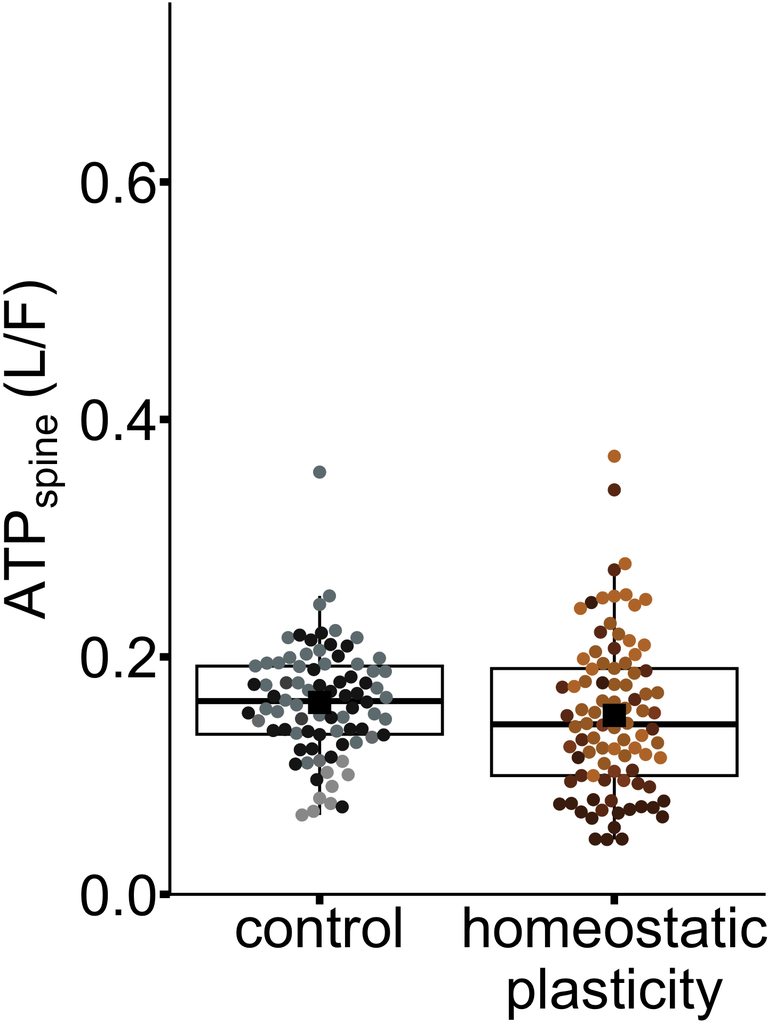

```r
set.seed(20261109)
date_levels <- levels(LbyF_df$Date)
date_colors <- c(
  setNames(rep(c("#9A9A9A", "#777B7E", "#4D4D4D", "#6F7C80", "#1A1A1A"), length.out = length(date_levels)), paste("Control", date_levels, sep = "_")),
  setNames(rep(c("#6B3518", "#8C4A24", "#A66A2C", "#4A240F", "#BC7734"), length.out = length(date_levels)), paste("TTX", date_levels, sep = "_"))
)
plot_stats <- tibble(group1_x = 1, group2_x = 2.2, stars = p_to_stars(condition_p)) %>% filter(stars != "ns")
fig2i_plot <- ggplot(LbyF_df, aes(x_pos, .data[[plot_y]], color = Date_Condition)) +
  geom_boxplot(aes(group = x_pos), fill = NA, width = 1, outlier.shape = NA, linewidth = 2, color = "black") +
  ggbeeswarm::geom_beeswarm(cex = 4, priority = "random", size = 8, corral = "random") +
  stat_summary(aes(group = x_pos), fun = mean, geom = "point", shape = 15, size = 15, color = "black") +
  geom_segment(data = plot_stats, aes(x = group1_x, xend = group2_x, y = 0.42, yend = 0.42),
               inherit.aes = FALSE, linewidth = 2, color = "black") +
  geom_text(data = plot_stats, aes(x = (group1_x + group2_x) / 2, y = 0.44, label = stars),
            inherit.aes = FALSE, size = 25, color = "black") +
  scale_x_continuous(breaks = unname(spacing_map),
                     labels = c("control", "homeostatic\nplasticity")) +
  scale_color_manual(values = date_colors) +
  scale_y_continuous(breaks = c(0, 0.2, 0.4, 0.6), expand = c(0, 0)) +
  coord_cartesian(ylim = c(0, 0.75)) +
  labs(x = NULL, y = expression(ATP[spine]~"(L/F)")) +
  theme_classic() +
  theme(axis.title = element_text(size = 80, color = "black"),
        axis.text = element_text(size = 80, color = "black"),
        axis.ticks = element_line(linewidth = 5, color = "black"),
        axis.ticks.length = grid::unit(0.5, "cm"),
        axis.line = element_line(linewidth = 2, color = "black"),
        legend.position = "none")
fig2i_plot
```

# Fig 2K

pH-corrected mitochondrial ATP time course following single-spine plasticity induction.

**update for 2026 pending** — The three regions have 15, 12, and 12 experiment dates. The v3 legend reports 11, 10, and 10 biological replicates.

**Source data**  
`Fig 2K.csv`, `Fig 2K pH.csv`

**Columns**

- `Date` — Experiment date
- `Condition` — Experimental condition
- `Dish` — Culture dish ID
- `Cell` — Cell ID
- `Mito` — Mitochondrial region ID
- `Time` — Time relative to induction (min)
- `L` — Luciferase luminescence
- `F` — Reporter fluorescence
- `LbyF` — Luminescence-to-fluorescence ratio (L/F)
- `region` — Juxtaspinal, non-juxtaspinal, or uninduced-spine region
- `Juxta` — Mean juxtaspinal mitochondrial pH
- `Juxta_SE` — SE of the corresponding mean pH
- `NonJuxta` — Mean non-juxtaspinal mitochondrial pH
- `NonJuxta_SE` — SE of the corresponding mean pH
- `Unstim` — Mean mitochondrial pH near uninduced spines
- `Unstim_SE` — SE of the corresponding mean pH

## Data

Regional pH is aligned by sampling index. L/F is pH-corrected (pKa 7.03) and plotted relative to the mean of the first nine valid baseline observations per trace.

```r
suppressPackageStartupMessages({
  library(dplyr); library(readr); library(ggplot2)
})
region_order <- c("stim_juxta", "stim_nonjuxta", "unstim")
region_labels <- c(stim_juxta = "juxta", stim_nonjuxta = "nonjuxta", unstim = "unstimulated")
region_colors <- c(stim_juxta = "#FC6A03", stim_nonjuxta = "#6B3518", unstim = "#777B7E")
X_BREAKS <- ERRORBAR_TIMES <- c(-2, 0, 2, 4, 6, 8, 10, 12)
N_BASELINE_POINTS <- 9; PKA_L <- 7.03
sem_fun <- function(x) { x <- x[is.finite(x)]; if (length(x) < 5) NA_real_ else sd(x) / sqrt(length(x)) }

Mito <- read_csv("./Fig 2K.csv", show_col_types = FALSE) %>%
  mutate(Date = trimws(as.character(Date)), Condition = trimws(as.character(Condition)),
         region = factor(region, levels = region_order),
         across(c(Dish, Cell, Mito, Time, L, F, LbyF), as.numeric),
         TraceID = paste(region, Date, Condition, Dish, Cell, Mito, sep = "_")) %>%
  filter(Condition == "Control", !is.na(region), !is.na(Date), Date != "",
         is.finite(Time), is.finite(L), is.finite(F), F != 0, is.finite(LbyF))
if (nrow(Mito) == 0) stop("No matching Fig 2K measurements were found.")

time_levels <- sort(unique(Mito$Time))
if (length(time_levels) < N_BASELINE_POINTS) stop("Fewer than nine ATP time points were found.")
Mito <- Mito %>% mutate(time_order = match(Time, time_levels),
                        BaselinePoint = time_order <= N_BASELINE_POINTS)

pH <- read_csv("./Fig 2K pH.csv", show_col_types = FALSE)
missing_columns <- setdiff(c("Time", "Juxta", "NonJuxta", "Unstim"), names(pH))
if (length(missing_columns)) stop("Missing pH columns: ", paste(missing_columns, collapse = ", "))
if (nrow(pH) < length(time_levels)) stop("The pH file has fewer rows than the ATP data have time points.")

pH <- pH %>% transmute(time_order = row_number(), Juxta = as.numeric(Juxta),
                       NonJuxta = as.numeric(NonJuxta), Unstim = as.numeric(Unstim)) %>%
  slice(seq_along(time_levels))
if (any(!is.finite(pH$Juxta)) || any(!is.finite(pH$NonJuxta)) || any(!is.finite(pH$Unstim)))
  stop("The pH file contains missing or nonnumeric pH values.")

juxta_baseline_pH <- mean(pH$Juxta[seq_len(N_BASELINE_POINTS)])
nonjuxta_baseline_pH <- mean(pH$NonJuxta[seq_len(N_BASELINE_POINTS)])
unstim_baseline_pH <- mean(pH$Unstim[seq_len(N_BASELINE_POINTS)])
pH <- pH %>% mutate(
  juxta_factor = (1 + 10^(PKA_L - Juxta)) / (1 + 10^(PKA_L - juxta_baseline_pH)),
  nonjuxta_factor = (1 + 10^(PKA_L - NonJuxta)) / (1 + 10^(PKA_L - nonjuxta_baseline_pH)),
  unstim_factor = (1 + 10^(PKA_L - Unstim)) / (1 + 10^(PKA_L - unstim_baseline_pH))
)

Mito <- Mito %>% left_join(pH, by = "time_order") %>%
  mutate(pH_value = case_when(region == "stim_juxta" ~ Juxta,
                              region == "stim_nonjuxta" ~ NonJuxta,
                              region == "unstim" ~ Unstim),
         pH_factor = case_when(region == "stim_juxta" ~ juxta_factor,
                               region == "stim_nonjuxta" ~ nonjuxta_factor,
                               region == "unstim" ~ unstim_factor),
         raw_value = (L * pH_factor) / F)
if (any(!is.finite(Mito$raw_value))) stop("The pH correction produced nonfinite L/F values.")

baseline_table <- Mito %>% filter(BaselinePoint) %>% group_by(region, TraceID) %>%
  summarise(Baseline = mean(raw_value), n_baseline = n_distinct(time_order), .groups = "drop") %>%
  filter(n_baseline == N_BASELINE_POINTS, is.finite(Baseline), Baseline != 0) %>%
  select(-n_baseline)
Mito <- Mito %>% inner_join(baseline_table, by = c("region", "TraceID")) %>%
  mutate(norm_value = raw_value / Baseline)
if (nrow(Mito) == 0) stop("No mitochondria had nine valid baseline points.")

Mito %>% select(Date, Condition, region, Dish, Cell, Mito, Time, L, F,
                pH_value, pH_factor, raw_value, norm_value) %>%
  mutate(across(where(is.numeric), ~ round(.x, 3)))
```

| Date | Condition | region | Dish | Cell | Mito | Time | L | F | pH_value | pH_factor | raw_value | norm_value |
| --- | --- | --- | --- | --- | --- | --- | --- | --- | --- | --- | --- | --- |
| 2023-08-06 | Control | stim_juxta | 1 | 1 | 1 | -2.667 | 200.392 | 2610.922 | 7.117 | 1.038 | 0.080 | 1.028 |
| 2023-08-06 | Control | stim_juxta | 1 | 1 | 1 | -2.333 | 189.686 | 2766.137 | 7.141 | 1.012 | 0.069 | 0.896 |
| 2023-08-06 | Control | stim_juxta | 1 | 1 | 1 | -2.000 | 180.216 | 2639.373 | 7.136 | 1.017 | 0.069 | 0.896 |
| 2023-08-06 | Control | stim_juxta | 1 | 1 | 1 | -1.667 | 198.725 | 2565.000 | 7.145 | 1.009 | 0.078 | 1.008 |
| 2023-08-06 | Control | stim_juxta | 1 | 1 | 1 | -1.333 | 225.137 | 2543.392 | 7.160 | 0.994 | 0.088 | 1.135 |
| 2023-08-06 | Control | stim_juxta | 1 | 1 | 1 | -1.000 | 200.451 | 2605.980 | 7.168 | 0.986 | 0.076 | 0.978 |
| 2023-08-06 | Control | stim_juxta | 1 | 1 | 1 | -0.667 | 191.275 | 2616.196 | 7.176 | 0.979 | 0.072 | 0.923 |
| 2023-08-06 | Control | stim_juxta | 1 | 1 | 1 | -0.333 | 220.078 | 2691.000 | 7.169 | 0.985 | 0.081 | 1.039 |
| 2023-08-06 | Control | stim_juxta | 1 | 1 | 1 | 0.000 | 236.176 | 2735.137 | 7.171 | 0.983 | 0.085 | 1.096 |
| 2023-08-06 | Control | stim_juxta | 1 | 1 | 1 | 2.000 | 328.824 | 2469.549 | 7.003 | 1.179 | 0.157 | 2.025 |

[output cut: 2310 more lines]

## Summary

```r
summary_table <- Mito %>% group_by(region) %>%
  summarise(n_Mitochondria = n_distinct(TraceID),
            n_Cells = n_distinct(Date, Condition, Dish, Cell),
            n_Experiment_Dates = n_distinct(Date), .groups = "drop") %>%
  mutate(Region = unname(region_labels[as.character(region)])) %>%
  select(Region, n_Mitochondria, n_Cells, n_Experiment_Dates) %>% as.data.frame()
summary_table
```

| Region | n_Mitochondria | n_Cells | n_Experiment_Dates |
| --- | --- | --- | --- |
| juxta | 25 | 20 | 15 |
| nonjuxta | 16 | 15 | 12 |
| unstimulated | 17 | 17 | 12 |

## Statistics

Repeated-measures ANOVA within region on pH-corrected L/F, with Greenhouse–Geisser correction and Tukey-adjusted period comparisons.

```r
block_levels <- c("Baseline", "At2min", "From2to6min", "From6to12min")
format_p <- function(p) ifelse(is.na(p), NA_character_,
                               ifelse(p < 0.0001, "<0.0001", sprintf("%.4f", p)))
p_to_stars <- function(p) case_when(
  is.na(p) ~ NA_character_, p < 0.0001 ~ "***", p < 0.001 ~ "***",
  p < 0.01 ~ "**", p < 0.05 ~ "*", TRUE ~ "ns"
)
block_data <- Mito %>%
  mutate(TimeBlock = case_when(BaselinePoint ~ "Baseline", near(Time, 2) ~ "At2min",
                               Time > 2 & Time < 6 ~ "From2to6min",
                               Time >= 6 & Time <= 12 ~ "From6to12min")) %>%
  filter(!is.na(TimeBlock), is.finite(raw_value)) %>%
  group_by(region, TraceID, TimeBlock) %>%
  summarise(LbyF = mean(raw_value), .groups = "drop") %>%
  mutate(TimeBlock = factor(TimeBlock, levels = block_levels))
posthoc_results <- list()
for (region_name in region_order) {
  region_data <- block_data %>% filter(region == region_name) %>%
    select(TraceID, TimeBlock, LbyF)
  complete_ids <- region_data %>% count(TraceID) %>% filter(n == 4) %>% pull(TraceID)
  region_data <- region_data %>% filter(TraceID %in% complete_ids) %>%
    mutate(TraceID = factor(TraceID), TimeBlock = factor(TimeBlock, levels = block_levels))
  if (n_distinct(region_data$TraceID) < 2) stop(paste("Too few complete mitochondria in", region_name))
  rm_aov <- suppressMessages(afex::aov_ez(
    id = "TraceID", dv = "LbyF", within = "TimeBlock", data = region_data,
    anova_table = list(correction = "GG")
  ))
  anova_p <- as.numeric(rm_aov$anova_table[["Pr(>F)"]][1])
  emmeans_table <- emmeans::emmeans(rm_aov, ~ TimeBlock)
  means <- as.data.frame(emmeans_table)
  comparisons <- as.data.frame(emmeans::contrast(emmeans_table, "pairwise", adjust = "tukey")) %>%
    filter(grepl("^Baseline - ", contrast)) %>%
    mutate(ComparedBlock = sub("^Baseline - ", "", contrast))
  baseline_index <- match("Baseline", as.character(means$TimeBlock))
  compared_index <- match(comparisons$ComparedBlock, as.character(means$TimeBlock))
  posthoc_results[[region_name]] <- tibble(
    region = region_name,
    ComparedBlock = case_when(comparisons$ComparedBlock == "At2min" ~ "2 min",
                              comparisons$ComparedBlock == "From2to6min" ~ ">2 to <6 min",
                              TRUE ~ "6-12 min"),
    `Baseline mean (SE)` = sprintf("%.3f (%.3f)", means$emmean[baseline_index], means$SE[baseline_index]),
    `Compared mean (SE)` = sprintf("%.3f (%.3f)", means$emmean[compared_index], means$SE[compared_index]),
    anova_p = anova_p, p_value = comparisons$p.value
  )
}
posthoc_df <- bind_rows(posthoc_results)
stats_table <- posthoc_df %>% transmute(
  Region = unname(region_labels[region]), Measure = "pH-corrected L/F",
  Test = "Repeated-measures ANOVA with Tukey post hoc",
  Comparison = paste("Baseline vs", ComparedBlock),
  `Baseline mean (SE)`, `Compared mean (SE)`,
  `ANOVA p` = format_p(anova_p), `Tukey p` = format_p(p_value)
) %>% as.data.frame()
stats_table
```

| Region | Measure | Test | Comparison | Baseline mean (SE) | Compared mean (SE) | ANOVA p | Tukey p |
| --- | --- | --- | --- | --- | --- | --- | --- |
| juxta | pH-corrected L/F | Repeated-measures ANOVA with Tukey post hoc | Baseline vs 2 min | 0.118 (0.016) | 0.211 (0.029) | <0.0001 | <0.0001 |
| juxta | pH-corrected L/F | Repeated-measures ANOVA with Tukey post hoc | Baseline vs >2 to <6 min | 0.118 (0.016) | 0.156 (0.024) | <0.0001 | 0.0075 |
| juxta | pH-corrected L/F | Repeated-measures ANOVA with Tukey post hoc | Baseline vs 6-12 min | 0.118 (0.016) | 0.146 (0.022) | <0.0001 | 0.0031 |
| nonjuxta | pH-corrected L/F | Repeated-measures ANOVA with Tukey post hoc | Baseline vs 2 min | 0.130 (0.025) | 0.184 (0.044) | 0.0283 | 0.0823 |
| nonjuxta | pH-corrected L/F | Repeated-measures ANOVA with Tukey post hoc | Baseline vs >2 to <6 min | 0.130 (0.025) | 0.144 (0.029) | 0.0283 | 0.0989 |
| nonjuxta | pH-corrected L/F | Repeated-measures ANOVA with Tukey post hoc | Baseline vs 6-12 min | 0.130 (0.025) | 0.142 (0.026) | 0.0283 | 0.0375 |
| unstimulated | pH-corrected L/F | Repeated-measures ANOVA with Tukey post hoc | Baseline vs 2 min | 0.187 (0.054) | 0.194 (0.048) | 0.7044 | 0.9382 |
| unstimulated | pH-corrected L/F | Repeated-measures ANOVA with Tukey post hoc | Baseline vs >2 to <6 min | 0.187 (0.054) | 0.185 (0.052) | 0.7044 | 0.9835 |
| unstimulated | pH-corrected L/F | Repeated-measures ANOVA with Tukey post hoc | Baseline vs 6-12 min | 0.187 (0.054) | 0.193 (0.062) | 0.7044 | 0.9529 |

## Plot

The red bar marks single-spine induction from 0 to 2 min.

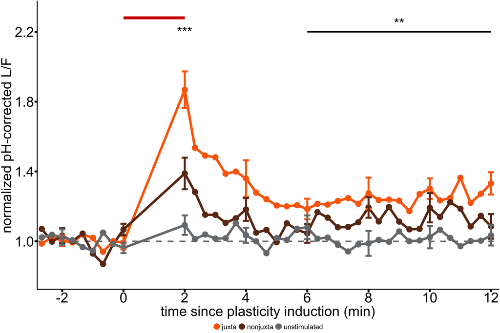

```r
set.seed(20261109)
norm_summary <- Mito %>% group_by(region, Time) %>%
  summarise(mean_value = mean(norm_value), n = sum(is.finite(norm_value)),
            sem = sem_fun(norm_value), .groups = "drop") %>%
  filter(n > 0, is.finite(mean_value))
norm_errorbars <- norm_summary %>%
  filter(round(Time, 8) %in% round(ERRORBAR_TIMES, 8), is.finite(sem))

juxta_stats <- posthoc_df %>% filter(region == "stim_juxta", p_value < 0.05) %>%
  mutate(stars = p_to_stars(p_value))
point_stars <- juxta_stats %>% filter(ComparedBlock == "2 min") %>%
  transmute(x = 2, y = 2.2, stars)
late_stars <- juxta_stats %>% filter(ComparedBlock == "6-12 min") %>%
  transmute(x_start = 6, x_end = 12, x_star = 9, y_bar = 2.2, y_star = 2.25, stars)

fig2k_plot <- ggplot(norm_summary, aes(Time, mean_value, color = region, group = region)) +
  geom_hline(yintercept = 1, color = "grey50", linetype = "dashed", linewidth = 3) +
  geom_line(linewidth = 5) + geom_point(size = 12) +
  geom_errorbar(data = norm_errorbars, aes(ymin = mean_value - sem, ymax = mean_value + sem),
                width = 0.2, linewidth = 4) +
  geom_text(data = point_stars, aes(x = x, y = y, label = stars),
            inherit.aes = FALSE, size = 20, color = "black") +
  geom_segment(data = late_stars, aes(x = x_start, xend = x_end, y = y_bar, yend = y_bar),
               inherit.aes = FALSE, color = "black", linewidth = 3) +
  geom_text(data = late_stars, aes(x = x_star, y = y_star, label = stars),
            inherit.aes = FALSE, size = 20, color = "black") +
  scale_color_manual(values = region_colors, breaks = region_order, labels = unname(region_labels[region_order])) +
  scale_x_continuous(breaks = X_BREAKS, expand = expansion(add = c(0.15, 0.15))) +
  scale_y_continuous(breaks = c(1, 1.4, 1.8, 2.2)) +
  coord_cartesian(ylim = c(0.8, 2.3)) +
  labs(x = "time since plasticity induction (min)", y = "normalized pH-corrected L/F") +
  annotate("segment",x=0,xend=2,y=2.28,yend=2.28,color="#D00000",linewidth=6) +
  theme_classic() +
  theme(axis.title = element_text(size = 60, color = "black"),
        axis.text = element_text(size = 60, color = "black"),
        axis.ticks = element_line(linewidth = 4, color = "black"),
        axis.ticks.length = grid::unit(0.4, "cm"),
        axis.line = element_line(linewidth = 2, color = "black"),
        legend.position = "bottom", legend.text = element_text(size=30), legend.title = element_blank())
fig2k_plot
```